# Advancing Risk Management in Commercial Banking with Knowledge Graphs

Author

Affiliation

Xin Xiang

[Georgetown University](https://www.georgetown.edu/)

Published

May 6, 2024

Abstract

In the fast growing financial industry, traditional risk control methods are increasingly unable to meet the demands of complex market dynamics and exploding corporate data. This paper discusses the application of knowledge graphs in the financial industry, with a particular focus on their utility in enhancing risk management in commercial banks. The use of structured data provides a new approach to enterprise risk assessment by providing interconnected data representation that is not available in traditional relational databases. In this paper, we demonstrate, through a case study, how knowledge graphs can be used to visualize and analyze corporate relationships and shareholder structures, thus providing important assistance in risk prediction and management. By constructing a detailed knowledge graph structure to map corporate entities, personal relationships, and shareholdings, our proposed model not only reduces the inefficiencies of traditional risk assessment methods, but also lowers the cost and improves the accuracy of predictions. This methodological shift is expected to provide a more integrated and proactive approach for risk management in finance, highlighting the potential of knowledge graphs to transform data into actionable insights. Future research will delve into the implications of equity structure and its realization of knowledge discovery and feature construction based on the equity knowledge graph.

## Introduction

In this project, I chose graph theory and graph structure as the theme, and would like to explain how graph theory can be applied in the traditional financial industry (e.g. commercial banks). In the face of the explosive growth of enterprise demand in the current financial era and the rapidly changing market environment, the original single-point breakthrough approach to risk control is far from being sufficient. There is an urgent need to analyze enterprise risk, improve work efficiency and reduce credit costs through scientific and technological means. When the traditional financial industry identifies and detects enterprise credit risk, most of the traditional methods are still used: on-site investigation, rule-based prediction and so on.

As we know that commercial banks have better customer data and transaction data, based on these data and the mining of structured and semi-structured data, through the knowledge graph in the vertical areas of commercial banks (e.g., shareholding relationship, etc.), we can dig and show a lot of details that we can not be found in ordinary relational databases [1]. In this way, by weaving a knowledge graph, we can assist in high risk management and control in the financial industry. In this way, we can enhance the ability of commercial banks to anticipate business risks, make early predictions, and avoid risks.

## Literature Review

### Knowledge graphs

The term “knowledge graph” first appeared in 1972, but the term was widely adopted after the release of Google Knowledge Graph in 2012 [2]. After the release of the knowledge graph, it quickly became popular in academia and industry Popularized and widely used in intelligent search, personalized recommendations, intelligence analysis, anti-fraud and other fields [3].

Knowledge graphs are a new way of representing knowledge. Essentially, the Semantic Web is an early form of Knowledge Graph. Knowledge graphs are abstract concepts describing entities and relationships between entities in the objective world, as well as networked knowledge bases consisting of entities, attributes and relationships [3]. A knowledge graph is a collection of concepts, entities and their relationships in the abstract physical world. Knowledge graphs change the traditional information retrieval methods. On the one hand, knowledge graphs describe semantic and attribute relationships between concepts and reason about them through fuzzy string matching. In turn, knowledge graphs show users categorized and arranged structured knowledge through a grid graphical information display interface [4]. At the same time, knowledge graph solves the problem of manually filtering useless information, which is of practical significance for the artificial intelligence society.

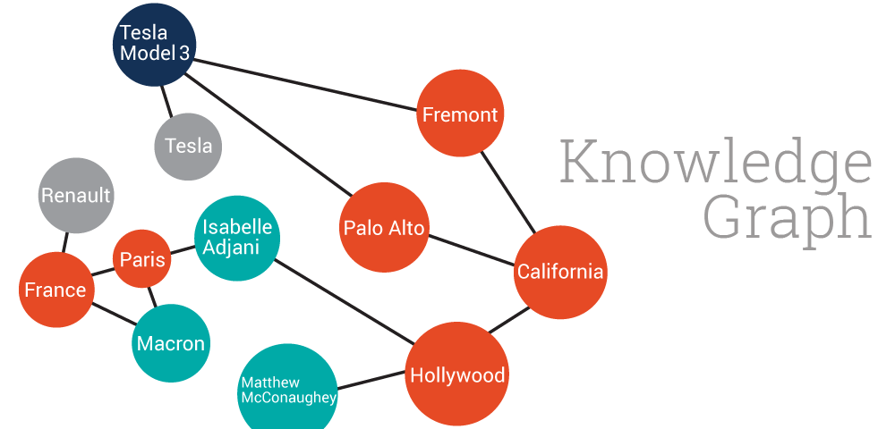

Fig. 1. Illustrative Knowledge Graph Demonstrating Connections Between Entities and Locations

Knowledge graph development is usually categorized into two types, top-down or bottom-up [5].

- The top-down approach refers to first defining an ontology (or data schema) and then extracting knowledge based on the ontology [6].
- Bottom-up approach means extracting knowledge from the data and defining the ontology of the knowledge graph based on the data [6].

### Big Data’s Role in Financial Systems Operations

At present, most areas of the financial system’s operations are related to big data, with trillions of pieces of data being constantly used within the system in day-to-day decision-making [7]. This is why Big Data is receiving more attention in the financial services sector, as information influences important success and productivity factors. It plays an increasingly important role in consolidating our understanding of financial markets. Particularly in trade and investment, tax reform, fraud detection and investigation, risk analysis and automation [8].

Moreover, it has transformed the financial industry by overcoming different challenges and gaining valuable insights to improve customer satisfaction and overall banking experience [9]. Razin [10] states that big data also transforms finance in five ways: creating transparency, analyzing risk, algorithmic trading, leveraging consumer data, and transforming culture. And this responds to the need to break down information barriers and create information linkages between financial systems.

Duan and Xiong [11] found that top-performing organizations use analytics almost five times more than lower-performing organizations when compared to intuition. Business analytics and business strategy must be tightly linked for better analytics-driven insights.Grover and Kar [12] mention that companies such as Apple, Facebook, Google, Amazon, and eBay regularly use digitized transactional data, such as regular storage of transaction times, purchase quantities, product prices, and customer credentials, to estimate market conditions to improve business operations [13, 14].

### The Applications of Knowledge Graphs in the Financial Risk Control Area

#### 1. Consumer Finance Fraud Detection

In recent years, consumer finance lending has spread across the globe as consumers have escalated. Credit cards, consumer loans, huabei, these endless forms of lending and platforms are characterized by small size, decentralization and high concurrency. And in the financial system, there is a risk known as app fraud risk. In the case of consumer finance loans, fraud risk means that the group or individual does not intend to repay the loan from the day the application is submitted. Fraudsters often provide false identities, contact information, equipment and asset information, etc [15]. Faced with this situation, banks and other financial systems need to anticipate the likelihood of becoming fraudulent from the applicant’s information in advance, to try to avoid the situation of having a loan that is not repaid. Since the last century, they have established a rule system based on expert experience.

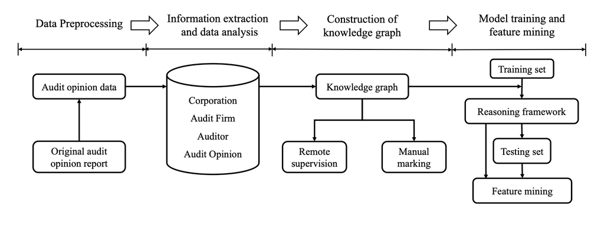

Fig. 2. The main workflow of using knowledge graph to detect fraud corporations

The rule system based on expert experience specifically includes: each time a fraud event is encountered, the system will record the characteristics of the event to form rules. When the next time an event with similar characteristics is encountered, the expert rule system triggers a warning or prevents the application from lending. However, capturing all the fraud characteristics is very difficult because new rules can only be created each time a fraud event occurs. And this, obviously, signifies that the expert rule system cannot predict what kind of fraudulent behavior will happen next time [16].

Using knowledge graphs, on the other hand, will provide great new horizons for fraud detection. Graph information (e.g., social network data) is used to extract features (e.g., degree centrality, connected components, and triangle counts). Then by designing rules, the accuracy of fraud detection can be improved based on a simple knowledge graph. For example, the following rule:

- A borrower is likely to be fraudulent if the borrower is connected to many other fraudulent borrowers.
- If Borrower A’s contact happens to use the same cell phone number as Borrower B’s contact, Borrower A is likely to be fraudulent, and Borrower B is also likely to be fraudulent. The number may be a proxy number for fraud.
- Use the information in the chart to find the contact information of the fraudulent borrower to recover or pull the plug.

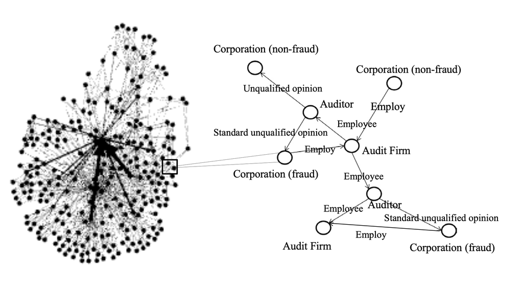

Fig. 3. Schematic diagram of audit information knowledge graph

#### 2. Risk Assessment and Management

In the field of risk control, risks often do not occur in isolation. For enterprise customers, with the continuous development of the capital chain, supply chain, guarantee chain, and conglomeration, it is easy to have a chain reaction like a fire [17]. The traditional risk control system is difficult to cope with such correlation risks, and the knowledge graph constructed based on graph data structure is an effective way to solve such problems. Knowledge graph technology can correlate isolated data from different data source systems, provide a unified view of customer risk, break information barriers, and effectively solve the problem of information asymmetry; it can also realize insights into customer relationship networks, effectively prevent and control associative risks, and improve risk control effectiveness.

According to business and data scenarios, three major corporation risk knowledge graph networks [18] can be formed as follows:

- **Corporation upstream and downstream knowledge graph:** Using bank flow and industry chain information, NLP technology is used to extract entities, relationships and attributes from unstructured data to build an industry chain knowledge graph. When the transaction volume and frequency between two companies exceed the preset threshold and the industry relationship conforms to the upstream and downstream model, their upstream and downstream relationships are confirmed.
- **Corporation investment and financing knowledge graph:** Combining public opinion, litigation and industrial and commercial data, and using NLP algorithm to process it, an investment and financing knowledge map including enterprises and individuals is formed. Financial disputes between individuals and businesses may hint at investment relationships.
- **Closely related to corporation knowledge graph:** Based on the company’s basic information, transaction data, and external public opinion, lawsuits, and industrial and commercial data, closely related information between companies is extracted. Capital transactions exceeding the threshold, cross-shareholder relationships, legal person relationships, multiple lawsuits, as well as financial transactions with individuals or executive shareholder relationships, etc., can all be regarded as close connections.

#### 3. Visual Analysis

With the continuous development of operations, the cross-industry operations, equity mergers and acquisitions and financing structures of credit-granting enterprises have become increasingly complex and hidden, which has brought huge challenges to the credit monitoring and risk assessment of commercial banks.

In the context of the accelerated financial digitalization agenda, commercial banks urgently need to promote technological innovation in risk management and accelerate digital transformation [17]. In order to solve the shortcomings of the traditional risk control model, the knowledge graph in the field of risk control can be used to convert redundant information and build a highly structured knowledge network.

These knowledge networks enable visualization by mapping knowledge resources into graphical elements, providing multi-dimensional insights and visualizing complex relationships between entities. For example, in their research, Wang et al. [19] built an end-to-end risk control domain knowledge graph based on transaction data, and stored the knowledge in the form of triples in the Neo4j graph database. This method not only displays the business relationships between customers, but also allows map users to have a more comprehensive understanding of the information through a combination of text lists and graphical visualizations, thereby more effectively monitoring and assessing risks.

## Close Corporation-related Knowledge Graph

### Description

In this study, the main focus is on visualization through the use of knowledge graphs of closely related corporations. We adopt a top-down approach to constructing the knowledge graph, specifically modeling stock holdings. Participating organizations include not only banks, but also non-banking financial institutions such as fund houses and securities firms, as well as non-financial institutions. Person nodes in the graph represent people connecting two or more institutions, and this diversity of node meanings complements previous research. In the construction of relationships among nodes, we mainly base on shareholding relationships, supplemented by employment and affinity relationships, and plot these relationships as edges.

For visualization, we designed a **query function** that allows users to search for the desired close firm relationship graph by node or relationship type. This design effectively reduces the interference of other irrelevant information during the visualization process, while aiding the user in a more direct assessment of the vertical direction of the holding relationships. In addition, we have introduced a degree-centeredness visualization feature that enables users to identify the most central companies or individuals in the query content. The integration of these functions not only improves the efficiency of information retrieval, but also enhances the operability and intuitiveness of the knowledge graph in practical applications.

### Data source

The data was from gihub project [Nebula Graph Shareholding project](https://github.com/wey-gu/nebula-shareholding-example/tree/main). And the author of the project says that the data was a faker data which will simulates the real situation and does not cause information leakage. So I borrowed the author’s data generator code and made changes to complete the data acquisition for this project.

There are various kinds of relationships when we checking corporations’ shareholding breakthrough, here let’s simplify it with only two kind of entities: person and corp, and with following relationship types.

- `person` can hold a `corp` in {share} %.
- `person` can be relative with another `person`.
- `corp` can hold another `corp` in {share} %.
- `corp` can be a branch of another `corp`.
- `person` can be as a role of a `corp`.

It can be found that by thinking and analyzing the above relationships, we get a ternary combination of this knowledge graph:

- **Entity:** Corporations, person.
- **Relationships:**
  - Relationships between Corporations such as investment, investment and financing, parent-subsidiary firms, etc. relationships.
  - Functions held between Corporations and person.
  - Affinity relationships between person and person.

### Code

#### Data preparation

Since the original dataset is stored in the graph database, you can set the tag and edge directly in the graph database, but I need to implement my own graph class in the example, so I need to do some preprocessing on the original dataset.

#### Data generators

Due to the large number of sample datasets on github, it may cause the visualization to be too complex and difficult to understand during simple graph visualization. So we simplify the dataset size and complexity by the following code for later presentation.

```python
import csv
import pandas as pd
from faker import Faker
from random import randint

PERSON_COUNT = 10
CORP_COUNT = 10
PERSON_SHAREHOLD_COUNT = 15
CORP_REL_COUNT = 10
CORP_SHAREHOLD_COUNT = 15
PERSON_REL_COUNT = 5
PERSON_ROLE_COUNT = 10

WRITE_BATCH = 10

faker = Faker()
Faker.seed(1234)  # Correct way to seed

def csv_writer(file_path, row_count, row_generator):
    with open(file_path, mode='w', newline='') as file:
        writer = csv.writer(file, delimiter=',', quotechar="'", quoting=csv.QUOTE_MINIMAL)
        csv_buffer = []
        used_pairs = set()  # Keep track of pairs already used
        while len(used_pairs) < row_count:
            new_row = row_generator()
            if new_row not in used_pairs:
                used_pairs.add(new_row)
                csv_buffer.append(new_row)
                if len(csv_buffer) >= WRITE_BATCH:
                    writer.writerows(csv_buffer)
                    csv_buffer = []
        if csv_buffer:
            writer.writerows(csv_buffer)

# Generate Persons and Corporations using Faker
def generate_person_data():
    data = {'person_id': ['p_' + str(i) for i in range(PERSON_COUNT)], 'person_name': [faker.name() for _ in range(PERSON_COUNT)]}
    return pd.DataFrame(data)

def generate_corp_data():
    data = {'corp_id': ['c_' + str(i) for i in range(CORP_COUNT)], 'corp_name': [faker.company() for _ in range(CORP_COUNT)]}
    return pd.DataFrame(data)

# Relationship generators
def person_share_generator():
    return ('p_' + str(randint(0, PERSON_COUNT - 1)), 'c_' + str(randint(0, CORP_COUNT - 1)), randint(0, 100))

def person_rel_generator():
    return ('p_' + str(randint(0, PERSON_COUNT - 1)), 'p_' + str(randint(0, PERSON_COUNT - 1)), randint(1, 3))

def corp_share_generator():
    return ('c_' + str(randint(0, CORP_COUNT - 1)), 'c_' + str(randint(0, CORP_COUNT - 1)), randint(0, 100))

def person_corp_role_generator():
    job_title = faker.job().replace(',', '')
    return ('p_' + str(randint(0, PERSON_COUNT - 1)), 'c_' + str(randint(0, CORP_COUNT - 1)), job_title)

# Writing the relationships to CSV
csv_writer('data/person_corp_share.csv', PERSON_SHAREHOLD_COUNT, person_share_generator)
csv_writer('data/person_rel.csv', PERSON_REL_COUNT, person_rel_generator)
csv_writer('data/corp_share.csv', CORP_SHAREHOLD_COUNT, corp_share_generator)
csv_writer('data/person_corp_role.csv', PERSON_ROLE_COUNT, person_corp_role_generator)
```

#### Import Data

In this step, we import CSV data from the Data Generator to generate data frames so that we can pass parameters to the `SelfdefinedGraph` class.

```python
import pandas as pd

# [1] corp.csv
# define the corporation id and name from the csv file
path1 = './data/corp.csv'
# load the csv into a DataFrame, and specify the column names
corp_df = pd.read_csv(path1)
#print(corp_df.head(6))

# [2] person.csv
# define the person id and name from the csv file
path2 = './data/person.csv'
person_df = pd.read_csv(path2)
#print(person_df.head(6))

# [3] person_rel.csv
# define the relationship degree of person id1 and id2 from the csv file
path3 = './data/person_rel.csv'
column_names = ['person_id1', 'person_id2','rel_degree']
person_rel_df = pd.read_csv(path3, header=None, names=column_names)
#print(person_rel_df.head(6))

# [4] corp_share.csv
# define the holdsharing of corporation id1 to id2 from the csv file
path5 = './data/corp_share.csv'
column_names = ['corp_id1', 'corp_id2','share_per']
corp_share_df = pd.read_csv(path5, header=None, names=column_names)
#print(corp_share_df.head(6))

# [5] person_corp_share.csv
# define the holdsharing of person id to the corporation id from the csv file
path6 = './data/person_corp_share.csv'
column_names = ['person_id', 'corp_id','share_per']
person_corp_share_df = pd.read_csv(path6, header=None, names=column_names)
#print(person_corp_share_df.head(6))

# [6] person_corp_role.csv
# define the role of person id in the corporation id from the csv file
path7 = './data/person_corp_role.csv'
column_names = ['person_id', 'corp_id','role']
person_corp_role_df = pd.read_csv(path7, header=None, names=column_names)
#print(person_corp_role_df.head(6))
```

**Corporation df**

```python
corp_df.head(6)
```

|  | corp_id | corp_name |
| --- | --- | --- |
| 0 | c_0 | Horn-Adams |
| 1 | c_1 | Mahoney, Chavez and Moreno |
| 2 | c_2 | David Inc |
| 3 | c_3 | Cook Ltd |
| 4 | c_4 | Sandoval-Jackson |
| 5 | c_5 | Matthews and Sons |

**Person df**

```python
person_df.head(6)
```

|  | person_id | person_name |
| --- | --- | --- |
| 0 | p_0 | Jessica Smith |
| 1 | p_1 | Teresa Aguilar |
| 2 | p_2 | Angela Miranda |
| 3 | p_3 | Andre Mccormick |
| 4 | p_4 | Marcus Gilbert |
| 5 | p_5 | Clayton Wilson |

**Person relationship df**

```python
person_rel_df.head(6)
```

|  | person_id1 | person_id2 | rel_degree |
| --- | --- | --- | --- |
| 0 | p_6 | p_2 | 3 |
| 1 | p_6 | p_5 | 3 |
| 2 | p_5 | p_4 | 3 |
| 3 | p_1 | p_7 | 1 |
| 4 | p_5 | p_2 | 3 |

**Corporation shareholding df**

```python
corp_share_df.head(6)
```

|  | corp_id1 | corp_id2 | share_per |
| --- | --- | --- | --- |
| 0 | c_4 | c_1 | 57 |
| 1 | c_4 | c_4 | 12 |
| 2 | c_1 | c_2 | 32 |
| 3 | c_0 | c_7 | 22 |
| 4 | c_5 | c_1 | 19 |
| 5 | c_3 | c_5 | 73 |

**Person corporation shareholding df**

```python
person_corp_share_df.head(6)
```

|  | person_id | corp_id | share_per |
| --- | --- | --- | --- |
| 0 | p_4 | c_0 | 0 |
| 1 | p_8 | c_0 | 12 |
| 2 | p_1 | c_4 | 89 |
| 3 | p_6 | c_0 | 0 |
| 4 | p_5 | c_0 | 79 |
| 5 | p_8 | c_0 | 2 |

**Person corporation role df**

```python
person_corp_role_df.head(6)
```

|  | person_id | corp_id | role |
| --- | --- | --- | --- |
| 0 | p_8 | c_0 | Prison officer |
| 1 | p_4 | c_6 | Commercial horticulturist |
| 2 | p_6 | c_8 | Actor |
| 3 | p_0 | c_8 | Chemical engineer |
| 4 | p_8 | c_0 | Television floor manager |
| 5 | p_5 | c_8 | Animal nutritionist |

#### Define the Class

```python
import networkx as nx
import matplotlib.pyplot as plt
from scipy import sparse
from scipy.sparse import coo_matrix

class SelfdefinedGraph:
    def __init__(self):
        self.adjacency_list = {}
        self.G = nx.DiGraph()

    def add_vertex(self, vertex, vertex_type):
        if vertex not in self.adjacency_list:
            self.adjacency_list[vertex] = {'type': vertex_type, 'edges': []}
            self.G.add_node(vertex, type=vertex_type)

    def add_edge(self, from_vertex, to_vertex, relationship_type, weight=None):
        if weight is not None:
            if from_vertex in self.adjacency_list:
                self.adjacency_list[from_vertex]['edges'].append({
                    'to': to_vertex,
                    'type': relationship_type,
                    'weight': weight
                })
                self.G.add_edge(from_vertex, to_vertex, weight=weight, type=relationship_type)

    def remove_vertex(self, vertex):
        if vertex in self.adjacency_list:
            # Remove all edges to this vertex
            for v in self.adjacency_list:
                self.adjacency_list[v]['edges'] = [e for e in self.adjacency_list[v]['edges'] if e['to'] != vertex]
            # Remove the vertex itself
            del self.adjacency_list[vertex]

    def remove_edge(self, from_vertex, to_vertex):
        if from_vertex in self.adjacency_list:
            self.adjacency_list[from_vertex]['edges'] = [
                e for e in self.adjacency_list[from_vertex]['edges'] if e['to'] != to_vertex
            ]

    def update_edge(self, from_vertex, to_vertex, new_weight):
        if from_vertex in self.adjacency_list:
            for edge in self.adjacency_list[from_vertex]['edges']:
                if edge['to'] == to_vertex:
                    edge['weight'] = new_weight

    def query_subset_by_node(self, node):
        if node not in self.adjacency_list:
            return {}  # Node does not exist

        subset = {}
        # Include directly connected nodes
        for n, props in self.adjacency_list.items():
            if n == node:
                subset[n] = props
            for edge in props['edges']:
                if edge['to'] == node:
                    if n not in subset:
                        subset[n] = {'type': self.adjacency_list[n]['type'], 'edges': []}
                    subset[n]['edges'].append(edge)
                if n == node:
                    if edge['to'] not in subset:
                        subset[edge['to']] = {'type': self.adjacency_list[edge['to']]['type'], 'edges': []}

        return subset

    def query_subset_by_relationship_type(self, relationship_type):
        subset = {}
        for node, properties in self.adjacency_list.items():
            # Filter edges to include only those of the specified type
            filtered_edges = [edge for edge in properties['edges'] if edge['type'] == relationship_type]
            if filtered_edges:
                # Only add the node if it has edges of the specified type
                if node not in subset:
                    subset[node] = {'type': properties['type'], 'edges': filtered_edges}

                # Include nodes connected by these edges to ensure the subset is complete
                for edge in filtered_edges:
                    target_node = edge['to']
                    if target_node not in subset:
                        target_node_edges = [e for e in self.adjacency_list[target_node]['edges'] if e['type'] == relationship_type]
                        subset[target_node] = {'type': self.adjacency_list[target_node]['type'], 'edges': target_node_edges}

        return subset
```

#### Graph construction

The following code shows how to initialize a graph and add nodes and edges to it. This includes adding individuals and companies to the graph as nodes, and adding edges that represent shareholding, kinship, and role relationships:

```python
# Initialize graph
graph = SelfdefinedGraph()

# Add persons and corps as vertices
for _, row in person_df.iterrows():
    graph.add_vertex(row['person_id'], 'person')
for _, row in corp_df.iterrows():
    graph.add_vertex(row['corp_id'], 'corp')

# Add relationship as edges
for _, row in person_corp_share_df.iterrows():
    graph.add_edge(row['person_id'], row['corp_id'], 'holds', row['share_per'])

for _, row in person_rel_df.iterrows():
    graph.add_edge(row['person_id1'], row['person_id2'], 'relative', row['rel_degree'])

for _, row in corp_share_df.iterrows():
    graph.add_edge(row['corp_id1'], row['corp_id2'], 'holds',row['share_per'])

for _, row in person_corp_role_df.iterrows():
    graph.add_edge(row['person_id'], row['corp_id'], 'roles', row['role'])
```

#### Visualizing graphical relationships

In order to more intuitively display and understand complex relationships in graphs, we used matplotlib and networkx libraries to create visual representations of graphs. The following code snippet demonstrates how to convert the adjacency list of a graph into a multiple directed graph and use different colors and labels to distinguish between different types of nodes and edges.

```python
import matplotlib.pyplot as plt
import networkx as nx
import matplotlib.patches as mpatches

def visualize_graph(adjacency_list):
    G = nx.MultiDiGraph()
    for node, properties in adjacency_list.items():
        G.add_node(node, type=properties['type'])
        for edge in properties['edges']:
            G.add_edge(node, edge['to'], weight=edge['weight'], relationship=edge['type'])
    plt.figure(figsize=(8,6))
    pos = nx.shell_layout(G)
    edge_colors = []
    for u, v, data in G.edges(data=True):
        color = '#0077B6' if data['relationship'] == 'holds' else '#023047' if data['relationship'] == 'relative' else '#FB8500'
        edge_colors.append(color)
        # Edge labels
        edge_label = f"{data['weight']}%" if isinstance(data['weight'], (int, float)) else f"{data['weight']}"
        mid_point_x, mid_point_y = (pos[u][0] + pos[v][0]) / 2, (pos[u][1] + pos[v][1]) / 2
        plt.text(mid_point_x, mid_point_y, edge_label, color='black', horizontalalignment='left', verticalalignment='center')

    # Drawing
    nx.draw_networkx_edges(G, pos, arrowstyle='-|>', arrowsize=15, edge_color=edge_colors, node_size=900)
    node_colors = ['#CAF0F8' if G.nodes[node]['type'] == 'person' else '#ffb703' for node in G]
    nx.draw_networkx_nodes(G, pos, node_color=node_colors, node_size=900)
    nx.draw_networkx_labels(G, pos)

    # Legends
    person_patch = mpatches.Patch(color='#CAF0F8', label='Person')
    corp_patch = mpatches.Patch(color='#ffb703', label='Corp')
    holds_patch = mpatches.Patch(color='#0077B6', label='Holds Relationship')
    relative_patch = mpatches.Patch(color='#023047', label='Relative Relationship')
    role_patch = mpatches.Patch(color='#FB8500', label='Role Relationship')
    legend = plt.legend(handles=[person_patch, corp_patch, role_patch, holds_patch, relative_patch], loc='upper left', bbox_to_anchor=(0.93, 0.95))
    plt.setp(legend.get_texts(), fontsize='small')
    legend.get_frame().set_linewidth(0.4)
    legend.set_title('Nodes & Edges Types', prop={'size': 'medium'})

    plt.title('Graph Visualization of Shareholding Relationships', fontsize=20)
    plt.axis('off')  # Turn off the axis
    plt.show()
```

By running the following code snippet, we can see a visual representation of each entity and relationship in the network, and further analyze and understand complex equity relationships. However, you will find that if you visualize the overall data, the specific details in the picture are still difficult to see clearly.

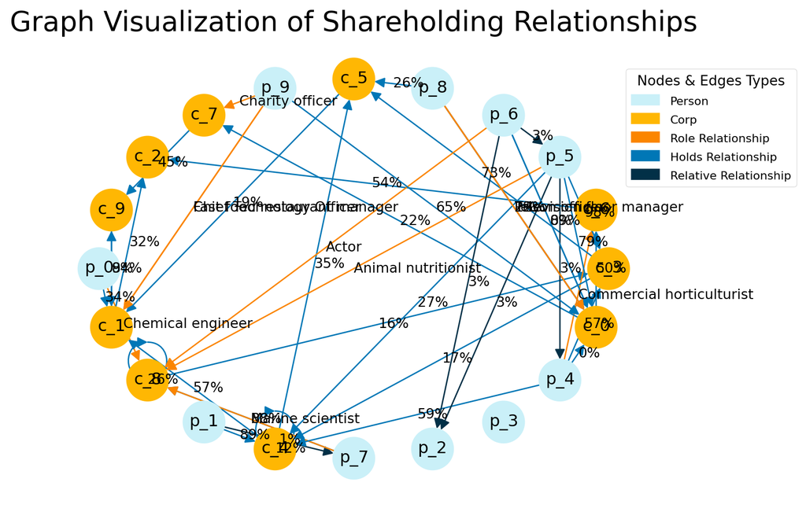

```python
adjacency_list = graph.adjacency_list
visualize_graph(adjacency_list=adjacency_list)
```

In the provided `SelfdefinedGraph` class, the functions `query_subset_by_node()` and `query_subset_by_relationship_type()` facilitate targeted queries within the graph structure. These functions are instrumental in retrieving and visualizing specific subsets of the graph based on node identity or relationship type. This capability enhances the clarity and conciseness of the visualizations by focusing on relevant aspects of the graph.

**1.Search by person/corporation**

By specifying nodes (people or companies), query and visualize the subset of the graph that is directly related to those nodes. This helps analyze the network structure of specific entities and their direct connections.

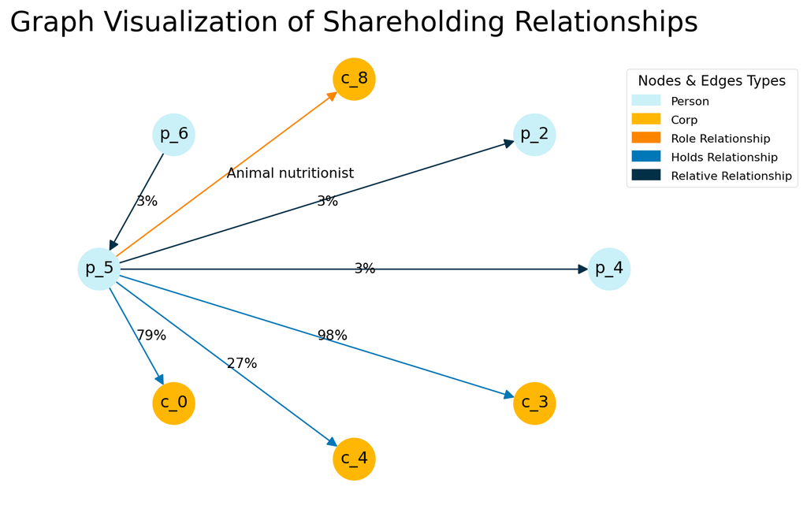

```python
sub_list1 = graph.query_subset_by_node('p_5')
visualize_graph(adjacency_list=sub_list1)
```

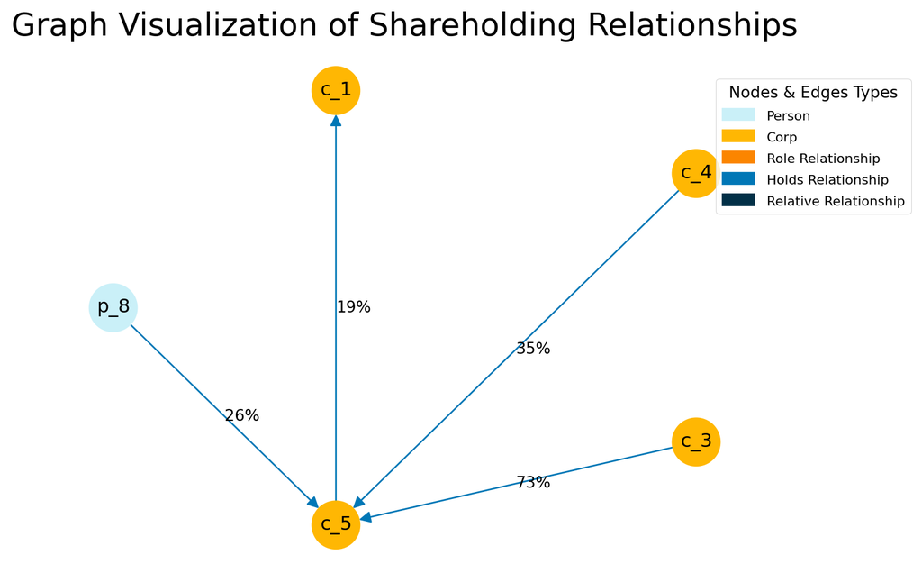

```python
sub_list2 = graph.query_subset_by_node('c_5')
visualize_graph(adjacency_list=sub_list2)
```

**2.Search by relationship type**

Filter and visualize the subset of graphs related to these relationships by specifying relationship types (e.g. ownership, kinship, role). This approach is particularly useful for analyzing specific types of interactions and connections.

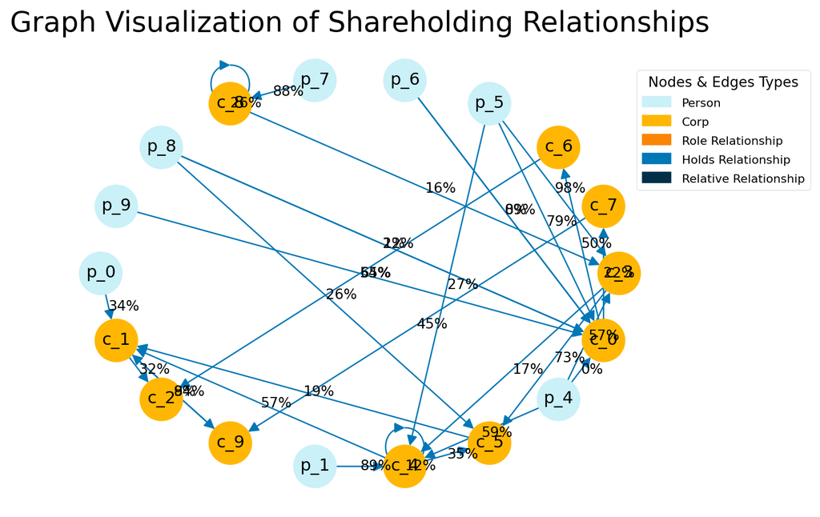

```python
sub_list3 = graph.query_subset_by_relationship_type('holds')
visualize_graph(adjacency_list=sub_list3)
```

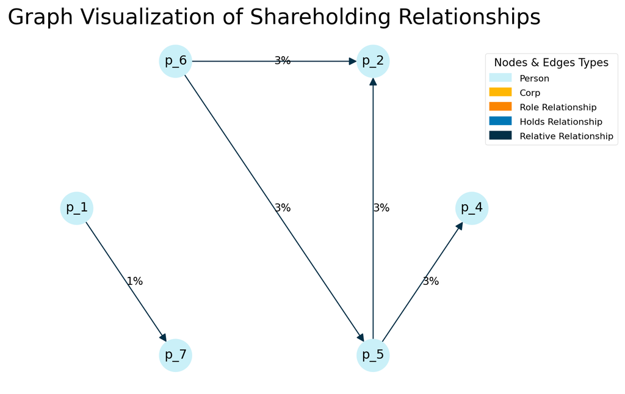

```python
sub_list4 = graph.query_subset_by_relationship_type('relative')
visualize_graph(adjacency_list=sub_list4)
```

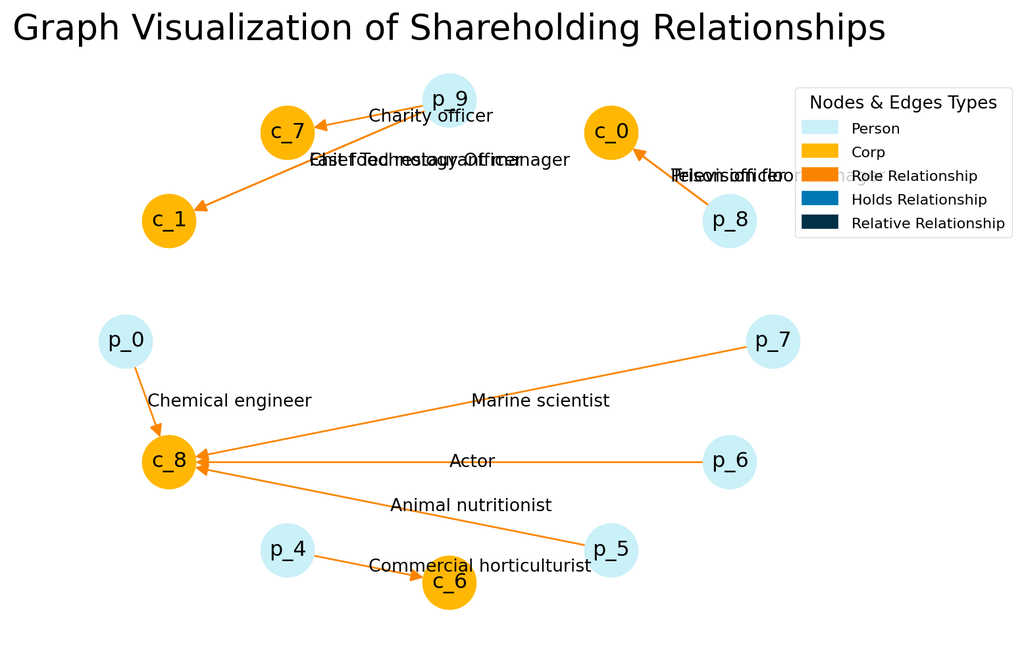

```python
sub_list5 = graph.query_subset_by_relationship_type('roles')
visualize_graph(adjacency_list=sub_list5)
```

#### Graphical Visualization of Degree Centrality

In order to analyze the influence of nodes in the network more deeply, we introduce the concept of degree centrality to measure the importance of nodes. The code example below shows how to integrate degree centrality into the visualization of a graph, allowing us to visually identify key nodes by their color intensity.

```python
import networkx as nx
import matplotlib.pyplot as plt
import matplotlib.patches as mpatches
import numpy as np
import matplotlib as mpl

def visualize_graph_with_centrality(adjacency_list):
    G = nx.MultiDiGraph()
    cmap = mpl.colormaps.get_cmap("Pastel2")
    new_colors = cmap(np.linspace(0, 1, 8))[:6]  # Select the first six colors
    new_cmap = mpl.colors.ListedColormap(new_colors)

    # Populate the graph with nodes and edges from the adjacency list
    for node, properties in adjacency_list.items():
        G.add_node(node, type=properties['type'])
        for edge in properties['edges']:
            G.add_edge(node, edge['to'], weight=edge['weight'], relationship=edge['type'])

    plt.figure(figsize=(8, 6))
    pos = nx.shell_layout(G)

    # Calculate centrality and use it for node color intensity
    centrality = nx.degree_centrality(G)
    # Normalize the values for better visualization
    node_colors = [centrality[node] for node in G.nodes()]

    # Drawing edges uniformly
    nx.draw_networkx_edges(G, pos, arrowstyle='->', arrowsize=15, edge_color='gray', node_size=800)

    # Drawing nodes uniformly sized
    uniform_node_size = 1000  # Set a uniform node size
    nx.draw_networkx_nodes(G, pos, node_color=node_colors, node_size=uniform_node_size, cmap=new_cmap)
    nx.draw_networkx_labels(G, pos)

    plt.title('Graph Visualization with Shareholding Centrality', fontsize=20)
    plt.axis('off')  # Turn off the axis
    plt.colorbar(plt.cm.ScalarMappable(cmap=new_cmap,norm=mpl.colors.Normalize(vmin=0, vmax=1)), ax=plt.gca(), orientation='vertical', label='Degree Centrality', fraction=0.03, pad=0.02,aspect=15)
    plt.show()
```

This visualization method not only highlights the key nodes in the network, but also intuitively shows the amount of influence of each node through color shades. This is crucial for analyzing important players in complex systems such as equity structures and social networks.

By running the following code snippet, we can obtain a network graph with metrics of degree centrality to more effectively reveal and understand the key dynamics and structures in the network.

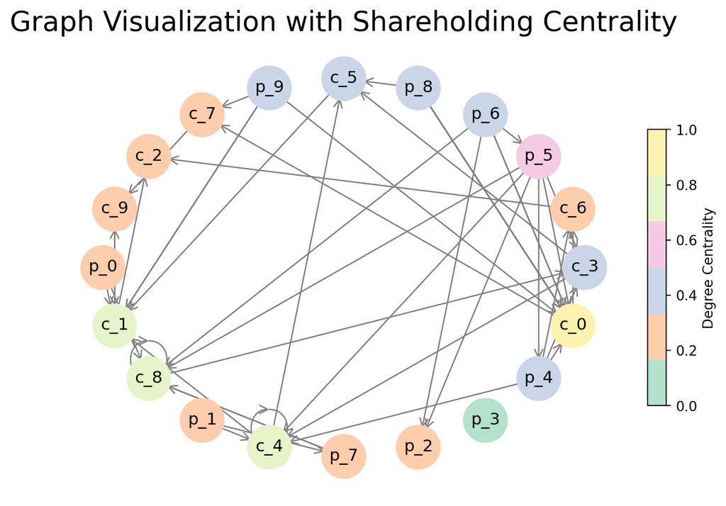

```python
visualize_graph_with_centrality(adjacency_list=adjacency_list)
```

As you can see from this graph, the centrality of the entire knowledge graph falls on the first corporation, which has the highest centrality. This also means that whether it is a company or an individual, the first corporation must be considered the leading company here.

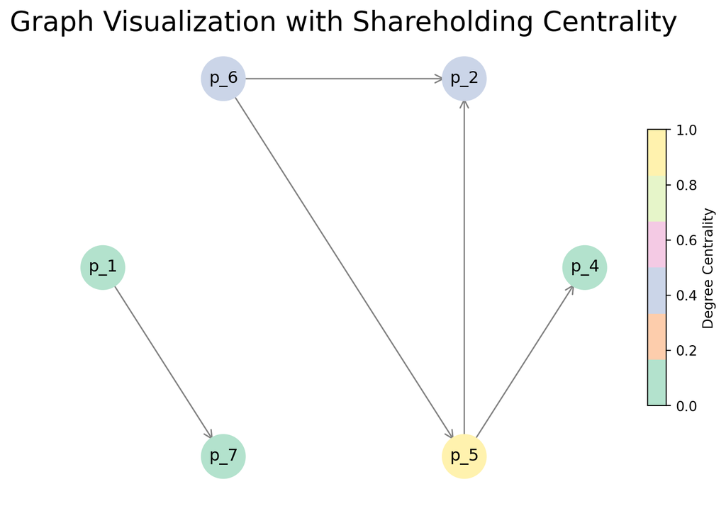

```python
visualize_graph_with_centrality(adjacency_list=sub_list4)
```

And when we narrow down the query to people who are related, we find that the person with id 5 shares kinship with all three people, while the others are not related as much as he is. The narrowed down one is clearer than the centrality of the knowledge graph degree for the whole list.

## Conclusion

This Study uses shareholding data to construct a detailed knowledge graph that depicts organizations and individuals as interconnected nodes. This method not only bridges the gaps identified in previous studies, but also enriches the understanding of complex network dynamics within the financial industry. The graph primarily demonstrates intricate shareholding relationships, but also contains other connections through employment and kinship, and is a prototype of a knowledge graph for associated corporations.

Through the graph data structure, this article creates a simple graph of shareholding relationships, transforming the more complex and underutilized shareholding structured data into clear and easy-to-understand graph data. This application can well assist the high-risk management and control of the financial industry. Future research based on this work can further explore shareholding penetration to infer detailed relationships such as holdings, shareholdings, concerted actions, related transactions, and common personnel on the basis of basic shareholding relationships, and realize knowledge discovery based on the financial shareholding knowledge map.

## References

1.

Huakui L, Liang H, Feicheng M (2020) Constructing knowledge graph for financial equities. Data Analysis and Knowledge Discovery 4(5):27–37

2.

Chah N (2018) OK google, what is your ontology? Or: Exploring freebase classification to understand google’s knowledge graph. arXiv preprint arXiv:180503885

3.

Hao X, Ji Z, Li X, et al (2021) Construction and application of a knowledge graph. Remote Sensing 13(13). https://doi.org/10.3390/rs13132511

4.

Xu Z, Sheng Y, He L, Wang Y (2016) Review on knowledge graph techniques. Journal of University of Electronic Science and Technology of China 45(4):589–606

5.

Fensel D, Şimşek U, Angele K, et al (2020) How to build a knowledge graph. Knowledge Graphs: Methodology, Tools and Selected Use Cases 11–68

6.

Li F, Xie W, Wang X, Fan Z (2020) Research on optimization of knowledge graph construction flow chart. In: 2020 IEEE 9th joint international information technology and artificial intelligence conference (ITAIC). IEEE, pp 1386–1390

7.

Ewen J (2019) How big data is changing the finance industry. Tamoco

8.

Hill C (2018) Where big data is taking the financial industry: Trends in 2018. Big data made simple

9.

Joshi N How big data can transform the finance industry. BBN times

10.

Razin E (2015) Big buzz about big data: 5 ways big data is changing finance. Forbes

11.

Duan L, Xiong Y (2015) Big data analytics and business analytics. Journal of Management Analytics 2(1):1–21

12.

Grover P, Kar AK (2017) Big data analytics: A review on theoretical contributions and tools used in literature. Global Journal of Flexible Systems Management 18:203–229

13.

Pousttchi K, Hufenbach Y (2014) Engineering the value network of the customer interface and marketing in the data-rich retail environment. International Journal of Electronic Commerce 18(4):17–42

14.

Thackeray R, Neiger BL, Hanson CL, McKenzie JF (2008) Enhancing promotional strategies within social marketing programs: Use of web 2.0 social media. Health promotion practice 9(4):338–343

15.

Wu H, Chang Y, Li J, Zhu X (2022) Financial fraud risk analysis based on audit information knowledge graph. Procedia Computer Science 199:780–787. https://doi.org/https://doi.org/10.1016/j.procs.2022.01.097

16.

Zhan Q, Yin H (2018) [A loan application fraud detection method based on knowledge graph and neural network](https://doi.org/10.1145/3194206.3194208). In: Proceedings of the 2nd international conference on innovation in artificial intelligence. Association for Computing Machinery, New York, NY, USA, pp 111–115

17.

Yuan J, Liu G, Liang H, Luo Q (2022) Summary of research and application of knowledge graphs in risk management field of commercial banks. Comput Eng Appl 58:37–52

18.

Xue C (2020) [The application of knowledge graph technology in commercial bank customer association risk early warning system](https://doi.org/10.1109/ICMCCE51767.2020.00238). In: 2020 5th international conference on mechanical, control and computer engineering (ICMCCE). pp 1083–1086

19.

Wang Z, Guo M, Li Z, Tang M, Yu J (2020) Knowledge graph construction for payment data risk control. In: Innovative computing: IC 2020. Springer, pp 1901–1907